# Demo

```python
import joblib
import pandas as pd
import numpy as np
import matplotlib.pyplot as plt
```

## Demo 0: Optimize Model

This is just a simple demo that you can see how I optimize PNL Curve step by step

And you can see the pnl Curve become more and more stable as training goes on

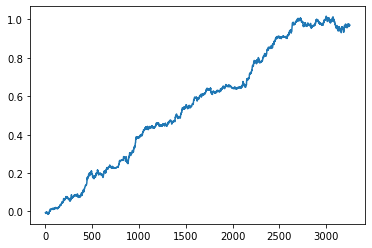

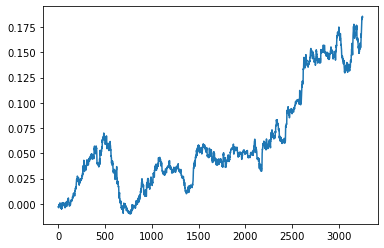

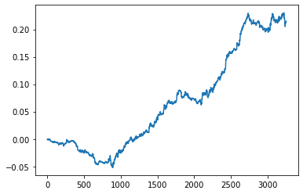

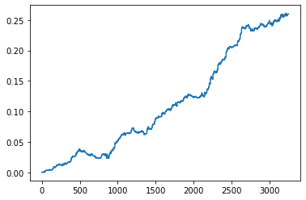

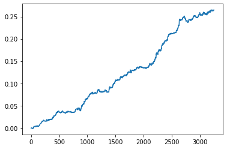

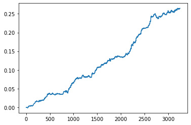

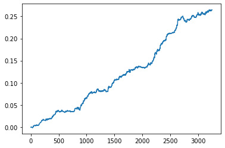

```python
from model.optDemo import optModel
feature_df,target_df=joblib.load('data/feature_ret.pickle')
target_df/=target_df.iloc[0]
feature_df.columns=[f'factor{i}' for i in range(feature_df.shape[1])]
ret_func=lambda df:df['PX_OPEN'].shift(-2)/df['PX_OPEN'].shift(-1)-1
model=optModel()
model.setData(feature_df,target_df)
model.transform(ret_func)
model.train()
```

## Demo 1: Single Ticker Strategy

In this case, you can see the result using different kinds of model

As model become more complex,in-sample result become much better, but out-of-sample result become worse when the model is too complex

```python
split_date='20180101'
X_train=feature_df.loc[:split_date]
X_test=feature_df.loc[split_date:]

Y_train=target_df.loc[:split_date]
Y_test=target_df.loc[split_date:]
```

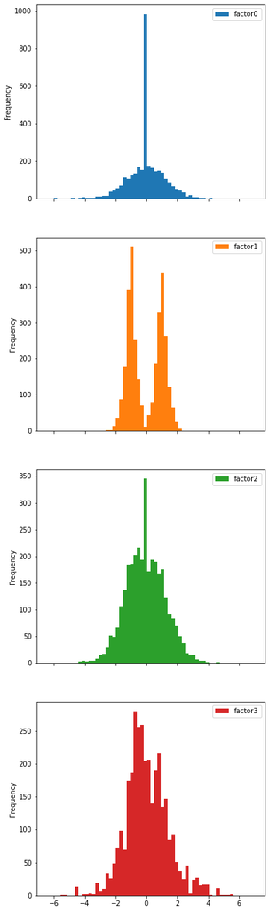

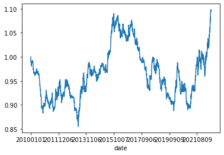

```python
plt.figure();feature_df.plot(kind='hist',bins=60,subplots=True,figsize=(6,24))
plt.figure();target_df['PX_OPEN'].plot()
```

```
---------- noParamModel ----------
('sharpe:', 2.067323345051003)
('sharpe:', 1.7547155472961318)
---------- linearModel ----------
('sharpe:', 2.1265759907965758)
('sharpe:', 2.3952651540348433)
---------- SVRModel ----------
('sharpe:', 3.5833486780630466)
('sharpe:', 0.9866824824980779)
```

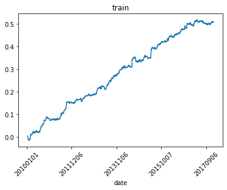

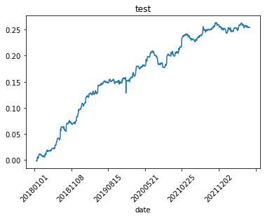

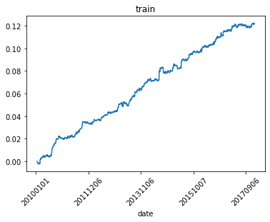

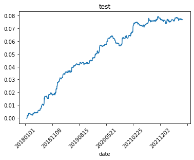

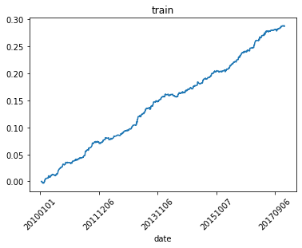

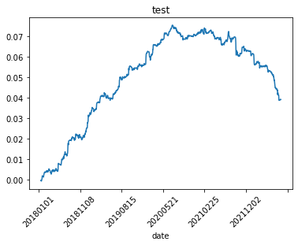

```python
from sklearn.linear_model import LinearRegression
from sklearn import svm
from model.modelDemo import InvestModel,NoParamModel
pred_models=[NoParamModel(),LinearRegression(),svm.SVR()]
names=['noParamModel','linearModel','SVRModel']
for pred_model,name in zip(pred_models,names):
    print('-'*10,name,'-'*10)
    model=InvestModel(pred_model)
    model.fit(X_train,Y_train)
    model.predict(X_test,Y_test)
    model.performance()
```

## Demo2: Basket Strategy

In this strategy, we trade a basket of tickers and decide what to buy or sell based on factors

```python
file=f'./data/basket.pickle'
X,Y=joblib.load(file)
curncys=np.unique(X.index.get_level_values(1))
curncys_dict=dict(zip(curncys,[f'C{i}' for i in range(len(curncys))]))
X.index=pd.MultiIndex.from_arrays([X.index.get_level_values(0),[curncys_dict[x] for x in X.index.get_level_values(1)]])
Y.index=pd.MultiIndex.from_arrays([Y.index.get_level_values(0),[curncys_dict[x] for x in Y.index.get_level_values(1)]])
split='20180101'
idx=pd.IndexSlice
X_test=X.loc[idx[split:,:]].swaplevel(0,1)
Y_test=Y.loc[idx[split:,:]].swaplevel(0,1)

X_train=X.loc[idx[:split,:]].swaplevel(0,1)
Y_train=Y.loc[idx[:split,:]].swaplevel(0,1)
```

```python
X.head(20)
```

| date |  | f1 | f2 |
| --- | --- | --- | --- |
| 20100101 | C1 | -2.449799 | -1.625818 |
|  | C2 | 0.395271 | 0.428410 |
|  | C3 | 0.477469 | 1.657194 |
|  | C4 | 0.010055 | -1.063016 |
|  | C5 | 0.377289 | -0.218813 |
|  | C6 | 0.394032 | 0.175149 |
|  | C7 | 0.396630 | 0.256005 |
|  | C8 | 0.399055 | 0.390889 |
| 20100104 | C1 | -2.452741 | -2.441748 |
|  | C2 | 0.393354 | 0.406084 |
|  | C3 | 0.444111 | 0.413810 |
|  | C4 | 0.026245 | -0.050394 |
|  | C5 | 0.390423 | 0.421849 |
|  | C6 | 0.391658 | 0.410696 |
|  | C7 | 0.403479 | 0.421623 |
|  | C8 | 0.403471 | 0.418081 |
| 20100105 | C1 | -2.395343 | -2.140964 |
|  | C2 | 0.440151 | 0.519911 |
|  | C3 | 0.458393 | 0.431872 |
|  | C4 | -0.273565 | -0.920200 |

```python
curncys=np.unique(X.index.get_level_values(1))
curncys_dict=dict(zip(curncys,[f'C{i}' for i in range(len(curncys))]))
X.index=pd.MultiIndex.from_arrays([X.index.get_level_values(0),[curncys_dict[x] for x in X.index.get_level_values(1)]])
X.head()
```

| date |  | f1 | f2 |
| --- | --- | --- | --- |
| 20100101 | C1 | -2.449799 | -1.625818 |
|  | C2 | 0.395271 | 0.428410 |
|  | C3 | 0.477469 | 1.657194 |
|  | C4 | 0.010055 | -1.063016 |
|  | C5 | 0.377289 | -0.218813 |

```python
Y.head(20)
```

```
date
20100101  C1   -5.160663
          C2   -5.092261
          C3   -0.553648
          C4    0.000000
          C5   -0.441490
          C6    0.000000
          C7   -3.993208
          C8   -3.040078
20100104  C1    1.381994
          C2   -1.434902
          C3   -2.151977
          C4   -2.074446
          C5    1.586863
          C6    0.459460
          C7   -0.232065
          C8   -0.632388
20100105  C1   -2.793257
          C2   -2.532458
          C3    2.106188
          C4   -1.345145
dtype: float64
```

```
---------- noParamModel ----------
1.4284988325375876
1.9354437054334537
---------- linearModel ----------
1.3859795256217944
1.7612326518269488
---------- SVRModel ----------
1.4412066861035273
-0.9237667969432526
```

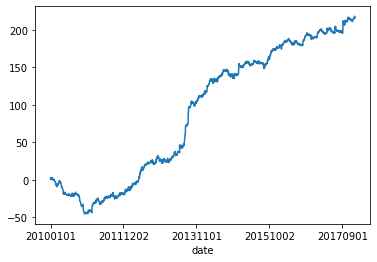

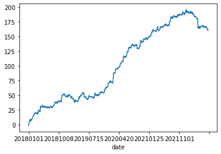

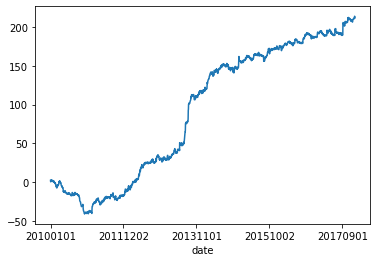

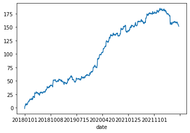

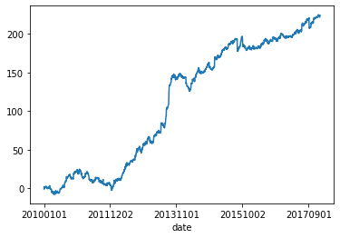

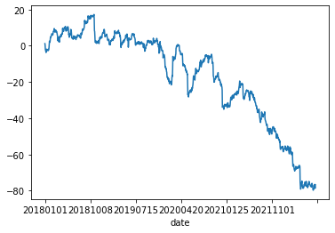

```python
from model.basketDemo import InvestModel,NoParamModel
pred_models=[NoParamModel(),LinearRegression(),svm.SVR()]
names=['noParamModel','linearModel','SVRModel']
for pred_model,name in zip(pred_models,names):
    print('-'*10,name,'-'*10)
    model=InvestModel(pred_model)
    plt.figure()
    model.fit(X_train,Y_train)
    plt.figure()
    model.predict(X_test,Y_test)
```

## Demo3: Random Factor

In order to test our model,getting rid of the effect of good factors, I will make some random features

you can see complex model can handle them well with in-sample data but not for out-of-sample data

And simple model will get bad results for both of them.

To make it sample,let's use single ticker strategy as out test

```python
feature_df,target_df=joblib.load('data/feature_ret.pickle')
feature_df=pd.DataFrame(np.random.normal(0,1,feature_df.shape),index=feature_df.index)
split_date='20180101'
X_train=feature_df.loc[:split_date]
X_test=feature_df.loc[split_date:]

Y_train=target_df.loc[:split_date]
Y_test=target_df.loc[split_date:]
```

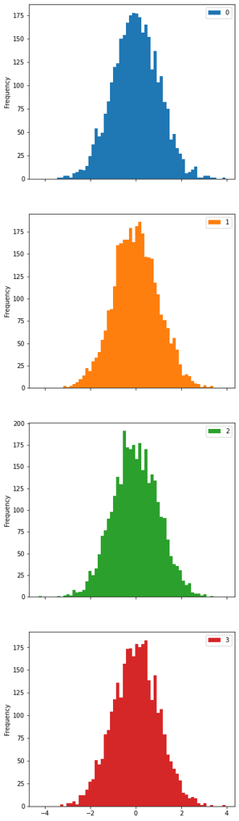

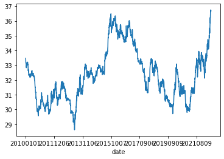

```python
plt.figure();feature_df.plot(kind='hist',bins=60,subplots=True,figsize=(6,24))
plt.figure();target_df['PX_OPEN'].plot()
```

```
---------- noParamModel ----------
('sharpe:', 0.5324152387821168)
('sharpe:', 0.7794795901436425)
---------- linearModel ----------
('sharpe:', 0.7839080840739103)
('sharpe:', 0.7024331243795866)
---------- SVRModel ----------
('sharpe:', 2.822972336491941)
('sharpe:', -0.06776462730975125)
```

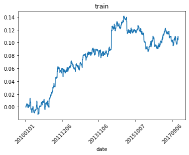

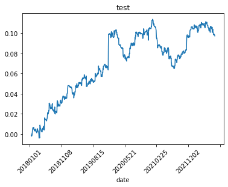

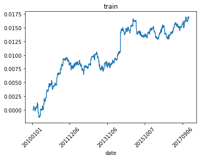

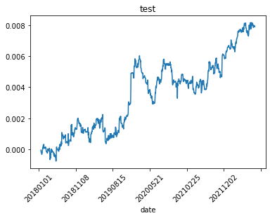

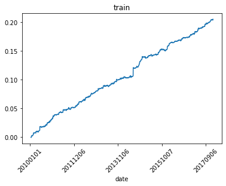

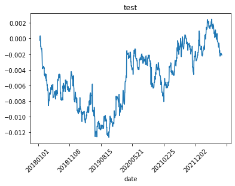

```python
from sklearn.linear_model import LinearRegression
from sklearn import svm
from model.modelDemo import InvestModel,NoParamModel
pred_models=[NoParamModel(),LinearRegression(),svm.SVR()]
names=['noParamModel','linearModel','SVRModel']
for pred_model,name in zip(pred_models,names):
    print('-'*10,name,'-'*10)
    model=InvestModel(pred_model)
    model.fit(X_train,Y_train)
    model.predict(X_test,Y_test)
    model.performance()
```

### If you are interested in my model and data, welcome to contact with me!